# SRPB traveling subjects reproducibility analysis

Brian B. Avants

2021-12-16

> “if not now, when?”

## reproducibility analysis for antspyt1w results

this documents different approaches to looking at reproducibility in numeric summary data derived from T1w images by ANTsX methods.

the `csv` results are generated from antspyt1w version 0.3.3.

- report overall reproducibility for a given region
- report a summary of cross-site agreement for a given region
- potentially look at effect sizes (though the variables are limited for this)
- we should distill the best of these measurements to a single funtion and then run on all of our derived variables — thereby assigning specific confidence to different measurements that we have.
- the `tarAnat` and `anatcsv` values should match. the analysis is then performed on whatever `roi$Description` matches the `tarAnat` `grep`.

```r
excludeSigna = TRUE # eliminate the really bad scanner
# demonstrate flexibility to analysis region
tarAnat='fusiform'
anatcsv='dktcortex.csv'
tarAnat='NBM'
tarAnat='CH13'
anatcsv='bf.csv'
```

## Demonstrate effect of subject vs effect of Scanner or Site: Raw data plots

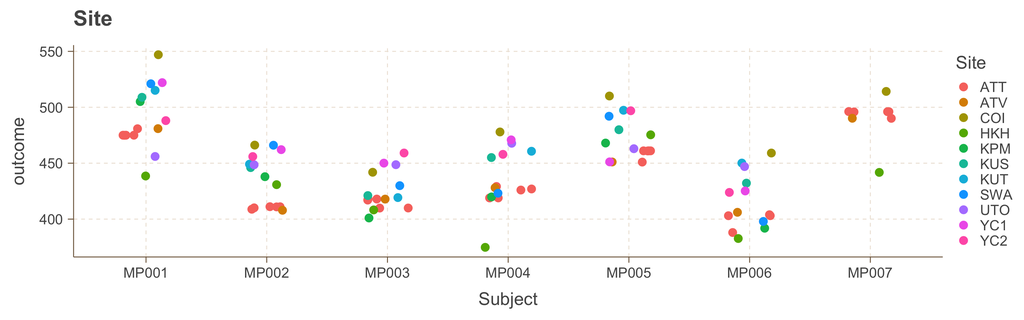

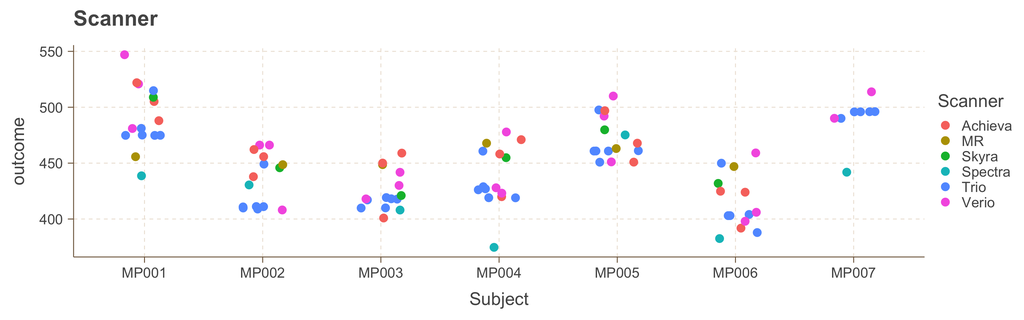

## Demonstrate effects of controlling for different variables with regression

What is the variability of the measurement if we control for age alone?

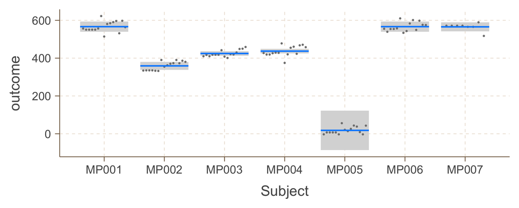

```r
mdl=(lm( outcome ~  age + Subject , data=dd ))
visreg::visreg( mdl, "Subject", gg=TRUE )
```

What is the reproducibility of the measurement if we control for age and scanner?

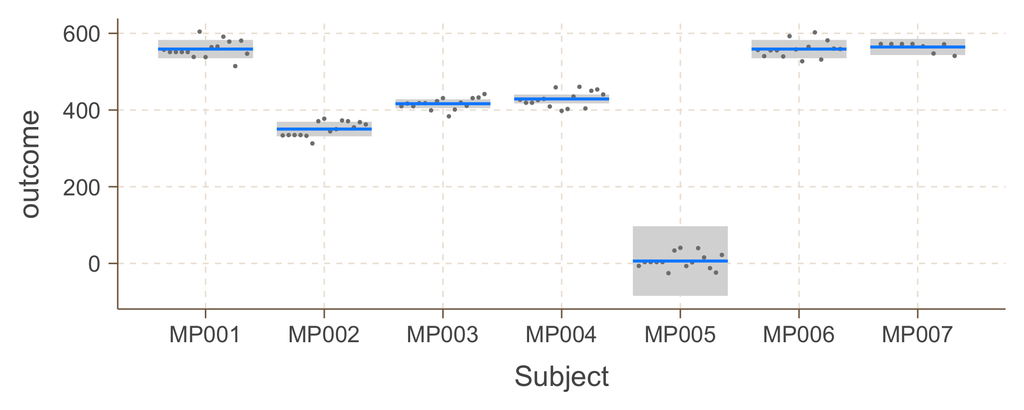

```r
mdl=(lm( outcome ~  age + Subject + Scanner + 1 , data=dd ))
visreg::visreg( mdl, "Subject", gg=TRUE )
```

```r
# grid.arrange( grobs = visreg::visreg( mdl, gg=TRUE ), ncol=1, main='reproducibility' )
```

What is the reproducibility of the measurement if we control for site?

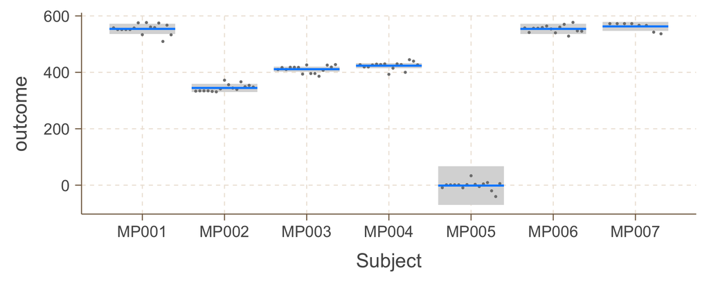

```r
mdl=(lm( outcome ~  age + Subject + Site + 1 , data=dd ))
visreg::visreg( mdl, "Subject", gg=TRUE )
```

```r
# grid.arrange( grobs = visreg::visreg( mdl, gg=TRUE ), ncol=1, main='reproducibility' )
```

What is the effect of total SNR?

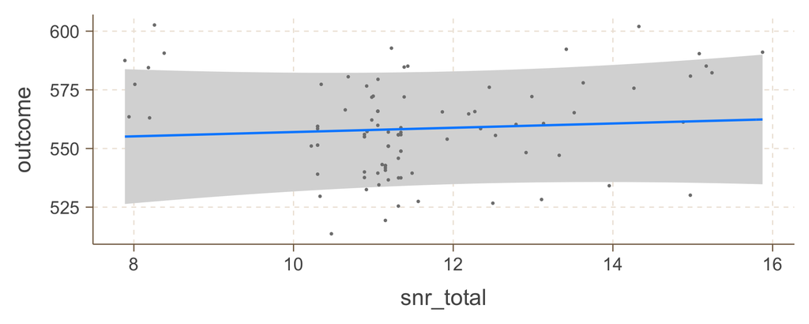

```r
mdl=(lm( outcome ~  age + Subject + Scanner + snr_total , data=dd ))
visreg::visreg( mdl, 'snr_total', gg=TRUE )
```

What is the effect of gray matter SNR?

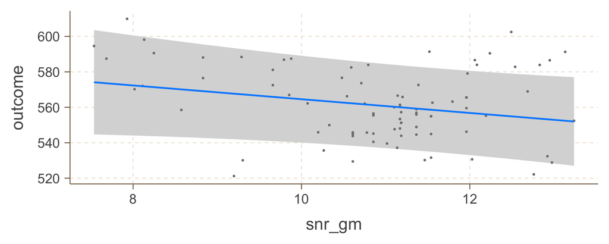

```r
mdl=(lm( outcome ~  age + Subject + Scanner + snr_gm , data=dd ))
visreg::visreg( mdl, 'snr_gm', gg=TRUE )
```

What is the effect of age if we control for the best confounds?

see the discussion of MRIQC [here](https://cpb-us-w2.wpmucdn.com/sites.brown.edu/dist/0/278/files/2021/10/MRIQC.pdf)

```r
library(lme4)
mdl0=(lm( outcome ~  age  +(Subject), data=dd ))
mycoffs0=coefficients(summary(mdl0))
mdl1=(lm( outcome ~  age  + Scanner + snr_total+ efc+(Subject), data=dd ))
summary(mdl1)
```

```
##
## Call:
## lm(formula = outcome ~ age + Scanner + snr_total + efc + (Subject),
##     data = dd)
##
## Residuals:
##     Min      1Q  Median      3Q     Max
## -42.093 -14.301  -0.482  14.011  48.550
##
## Coefficients: (1 not defined because of singularities)
##                 Estimate Std. Error t value Pr(>|t|)
## (Intercept)    -1329.971    210.805  -6.309 1.30e-08 ***
## age               73.741      8.069   9.139 3.44e-14 ***
## ScannerMR         -2.055     11.924  -0.172 0.863556
## ScannerSkyra      -3.860     13.266  -0.291 0.771814
## ScannerSpectra   -42.435     10.998  -3.858 0.000225 ***
## ScannerTrio      -21.608      9.693  -2.229 0.028490 *
## ScannerVerio      -2.337     12.420  -0.188 0.851203
## snr_total          0.543      1.905   0.285 0.776295
## efc              -30.177     36.005  -0.838 0.404365
## SubjectMP002    -203.463     20.636  -9.860 1.25e-15 ***
## SubjectMP003    -138.941     13.497 -10.294  < 2e-16 ***
## SubjectMP004    -125.060     14.204  -8.805 1.61e-13 ***
## SubjectMP005    -532.808     61.177  -8.709 2.49e-13 ***
## SubjectMP006          NA         NA      NA       NA
## SubjectMP007      10.704     10.684   1.002 0.319295
## ---
## Signif. codes:  0 '***' 0.001 '**' 0.01 '*' 0.05 '.' 0.1 ' ' 1
##
## Residual standard error: 20.41 on 83 degrees of freedom
## Multiple R-squared:  0.7275, Adjusted R-squared:  0.6848
## F-statistic: 17.04 on 13 and 83 DF,  p-value: < 2.2e-16
```

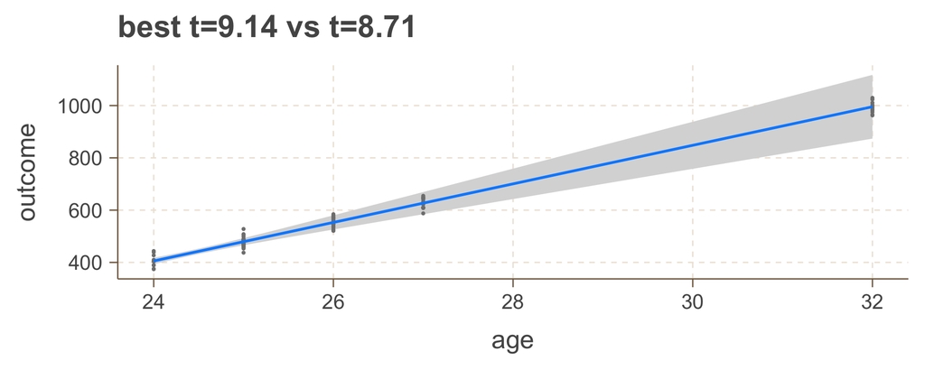

```r
mycoffs1=coefficients(summary(mdl1))
# mdl=(lm( outcome ~  age   +(Subject), data=dd ))
ttl=paste0("best t=",
  format(mycoffs1["age",3],digits=3),
  " vs t=",format(mycoffs0["age",3],digits=3))
visreg::visreg( mdl1, 'age', gg=TRUE ) + ggtitle(ttl)
```

What is the reproducibility of the measurement if we control for a motion specific variable?

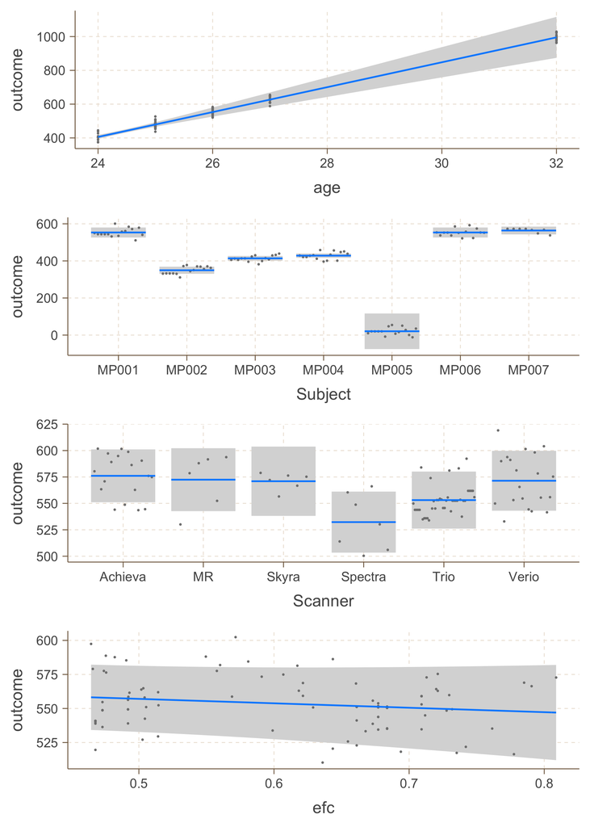

```r
mdl=(lm( outcome ~  age + Subject + Scanner + efc , data=dd ))
grid.arrange( grobs = visreg::visreg( mdl, gg=TRUE ), ncol=1, main='reproducibility' )
```

## show volumes for one subject at different sites

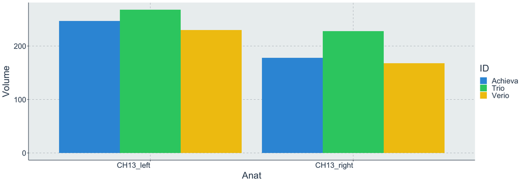

```r
ggthemr("flat")
nvols = length( roi$Description[roisel] )
dfvols = data.frame( matrix( nrow=3, ncol=nvols+1) )
colnames(dfvols)=c("ID",roi$Description[roisel])
ct=0
for ( j in  c(86,88,93)) {
  myid = dd[j,"participants_id"]
  fn = paste0( rdir, "/SRPBTravel/", myid,
    "/T1wHierarchical/SRPBTravel-",myid,"-T1wHierarchical-", anatcsv )
  if( file.exists( fn ) ) {
    roi = read.csv( fn )
    ct=ct+1
    roisel = grep(tarAnat,roi$Description)
    dfvols[ct,] = c(  dd[j,"Scanner"],roi$VolumeInMillimeters[roisel])
    }
  }
dflong = pivot_longer( dfvols, names(dfvols)[-1] )
dflong$ID=factor(dflong$ID)
names(dflong)=c("ID","Anat","Volume")
dflong$Volume = as.numeric( dflong$Volume )
ylims = c( median(dflong$Volume ), max(dflong$Volume)+0.05*max(dflong$Volume))
ggplot(dflong, aes(fill=ID, y=Volume, x=Anat)) +
    geom_bar(position="dodge", stat="identity")+
      theme(text = element_text(size=22),
        axis.text.x = element_text(angle=0, hjust=1))
```

## Summmary reliability data: statistical measures of reproducibility

```r
print( reli_stats( "outcome", "Scanner", "Subject", data=dd ) )
```

```
##
## Coefficient of Variation (%):  4.25
## Standard Error of Measurement (SEM):  20.3199
## Standard Error of the Estimate (SEE):  45.8908
## Standard Error of Prediction (SEP):  71.0744
##
## Intraclass Correlation Coefficients
##            model         measures  type    icc lower.ci upper.ci
## 1 one-way random        Agreement  ICC1 0.6111   0.3615   0.8652
## 2 two-way random        Agreement  ICC2 0.6197   0.3639   0.8684
## 3  two-way fixed      Consistency  ICC3 0.7150   0.4841   0.9093
## 4 one-way random   Avg. Agreement ICC1k 0.9041   0.7725   0.9747
## 5 two-way random   Avg. Agreement ICC2k 0.9072   0.7744   0.9754
## 6  two-way fixed Avg. Consistency ICC3k 0.9377   0.8492   0.9836
```

## Site-wise reliability

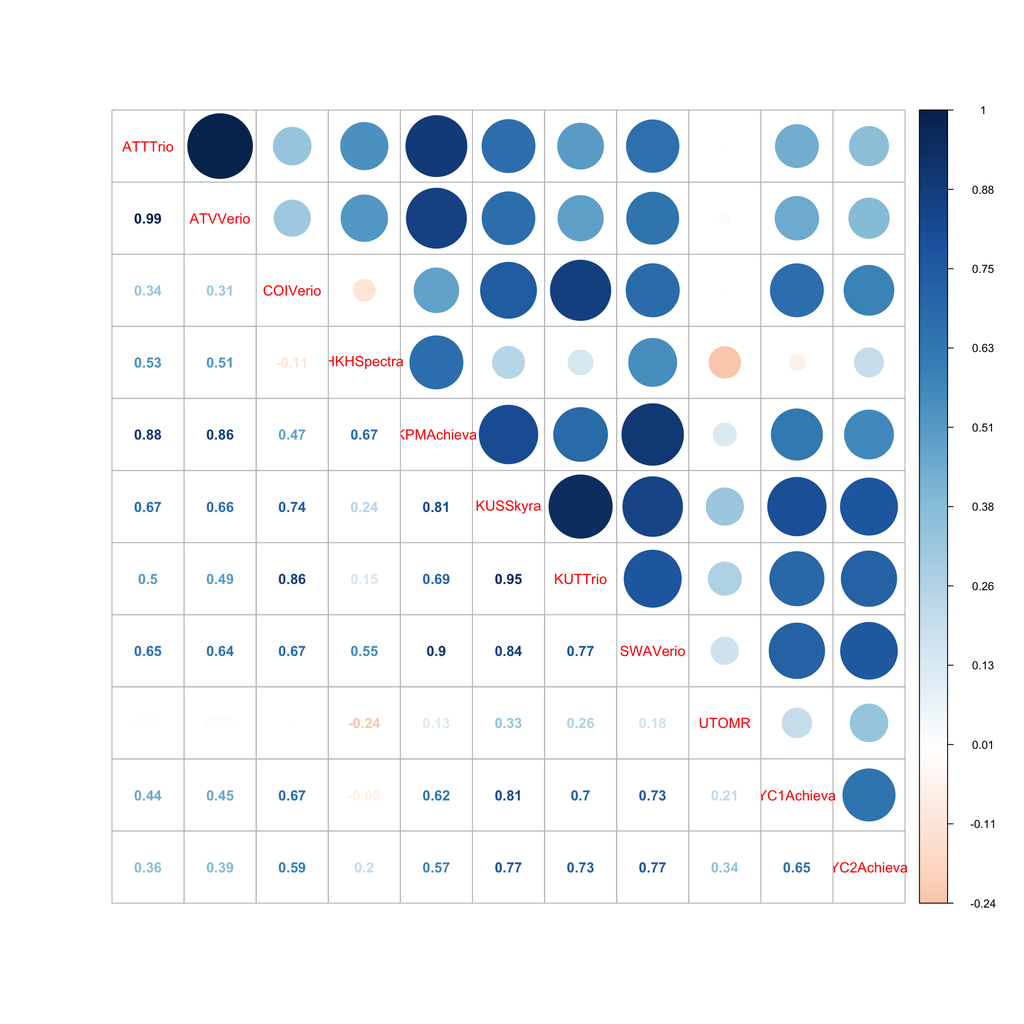

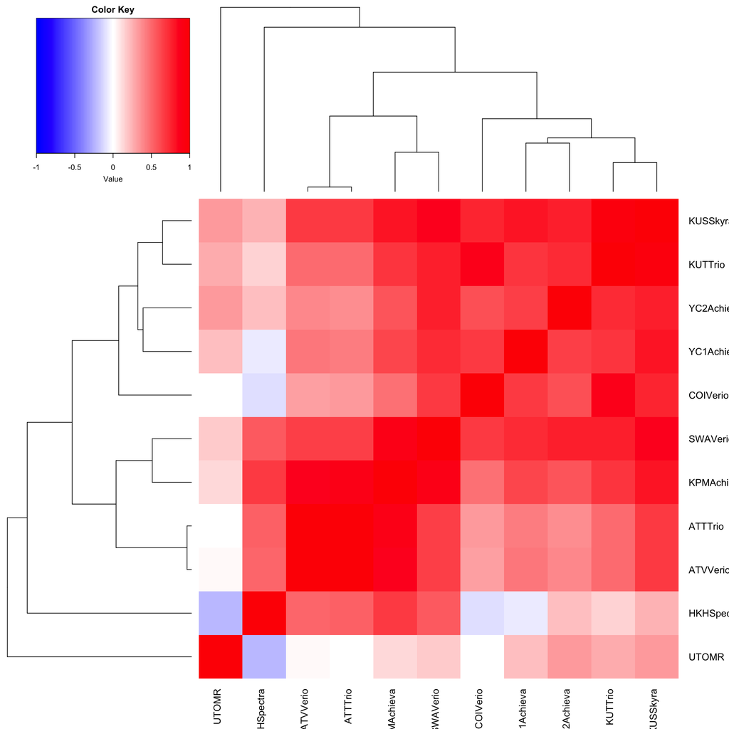